# Modeling and prediction for movies

## Setup

### Load packages

```r
library(dplyr)
library(statsr)
library(ggplot2)
library(cowplot)
library(RColorBrewer)
```

### Load data

```r
load("movies.Rdata")
```

## Part 1: Data

The dataset information is about movies contains 651 randomly sampled movies produced and released before 2016. This data set comes from Rotten Tomatoes and IMDB with total 32 available variables.

### Generabizability

The data is randomly sampled and it’s big enough (651 observations) so the generabizability principle is achieved.

### Causality

The data is an observational and hence we can not conclude causality from it. We are only able to show association between variables in this dataset.

## Part 2: Research question

What factors are associated with a movie’s audience score?

This is an interesting question. By answering this, we could predict a movie’s audience score with certain information. Based on this, we will understand the factors that influence the audience evaluation of a movie.

## Part 3: Exploratory data analysis

First, we choose `audience_score` as the response variable and we select all variables we needed.

```r
# filter variables in movie dataset
movies <- movies %>% select(audience_score, genre, runtime, mpaa_rating, thtr_rel_month, best_pic_nom, best_actor_win, best_actress_win, best_dir_win, top200_box, imdb_rating, critics_score,) %>% na.exclude()
```

We could create some plots to show the relations between average rating score and different factors.

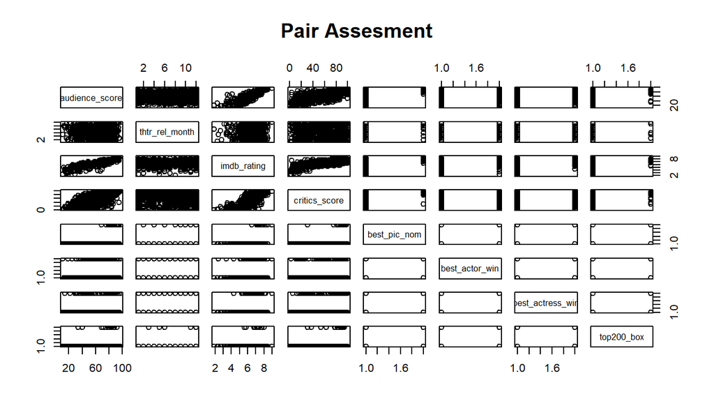

```r
pairs(~audience_score+thtr_rel_month+imdb_rating+critics_score+best_pic_nom+best_actor_win+best_actress_win+top200_box,
      data=movies,
   main="Pair Assesment")
```

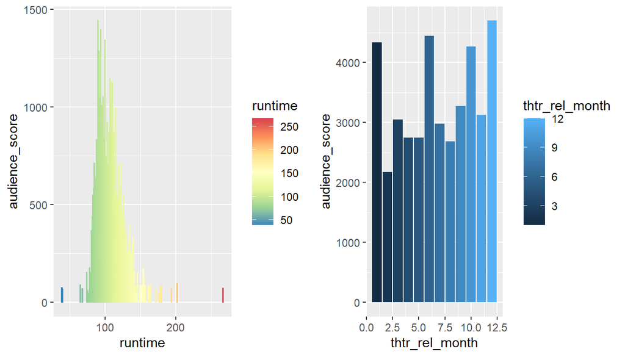

```r
p1 <- ggplot(data = movies, aes(x = runtime, y = audience_score, color = runtime)) + geom_col() +
  scale_color_distiller(palette = "Spectral")

p2 <- ggplot(data = movies, aes(x = thtr_rel_month , y = audience_score, fill =thtr_rel_month)) + geom_col() +
  scale_color_distiller(palette = "Greens")

plot_grid(p1, p2)
```

```r
movies %>% group_by(genre) %>% summarise(audience_score_by_genre = mean(audience_score)) %>% arrange(desc(audience_score_by_genre))
```

```
## # A tibble: 11 x 2
##    genre                     audience_score_by_genre
##    <fct>                                       <dbl>
##  1 Documentary                                  83.0
##  2 Musical & Performing Arts                    80.2
##  3 Other                                        66.7
##  4 Drama                                        65.3
##  5 Art House & International                    64
##  6 Animation                                    62.4
##  7 Mystery & Suspense                           55.9
##  8 Action & Adventure                           53.8
##  9 Comedy                                       52.5
## 10 Science Fiction & Fantasy                    50.9
## 11 Horror                                       45.8
```

```r
movies %>% group_by(mpaa_rating) %>% summarise(audience_score_by_mpaa_rating = mean(audience_score)) %>% arrange(desc(audience_score_by_mpaa_rating))
```

```
## # A tibble: 6 x 2
##   mpaa_rating audience_score_by_mpaa_rating
##   <fct>                               <dbl>
## 1 Unrated                              78.6
## 2 G                                    68.5
## 3 NC-17                                63.5
## 4 R                                    62.0
## 5 PG                                   61.8
## 6 PG-13                                56.7
```

From the figure we could see that those movies around 100 mins have better rating scores, while the difference between months is not as obvious as movie length. Movies released in 1, 6, 10 and 12 month have better rating scores.

Documentary have highest average rating score and unrated movies have highest average rating score.

We then visualize the relation between Oscar rewards and audience scores.

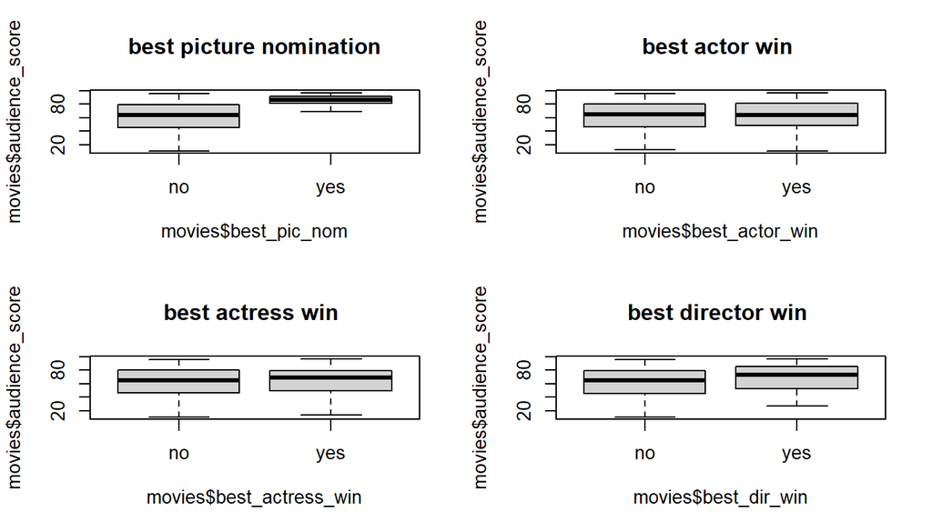

```r
par(mfrow = c(2,2))

plot(movies$audience_score ~ movies$best_pic_nom , main = "best picture nomination")

plot(movies$audience_score ~ movies$best_actor_win, main = "best actor win ")

plot(movies$audience_score ~ movies$best_actress_win, main = "best actress win ")

plot(movies$audience_score ~ movies$best_dir_win , main = "best director win ")
```

We could see that movies with best picture nomination or best director reward tend to have higher rating scores. Meanwhile, best actress or best actor rewards have weaker association with rating scores.

## Part 4: Modeling

We could build our first model.

```r
l_m <- lm(data = movies, audience_score ~ genre + runtime + mpaa_rating + best_pic_nom + best_dir_win + thtr_rel_month + imdb_rating + critics_score + best_actor_win + best_actress_win + top200_box)
summary(l_m)
```

```
##
## Call:
## lm(formula = audience_score ~ genre + runtime + mpaa_rating +
##     best_pic_nom + best_dir_win + thtr_rel_month + imdb_rating +
##     critics_score + best_actor_win + best_actress_win + top200_box,
##     data = movies)
##
## Residuals:
##     Min      1Q  Median      3Q     Max
## -28.330  -6.175   0.238   5.455  50.222
##
## Coefficients:
##                                 Estimate Std. Error t value Pr(>|t|)
## (Intercept)                    -33.99290    4.34684  -7.820 2.25e-14 ***
## genreAnimation                   9.31235    3.84548   2.422  0.01573 *
## genreArt House & International  -0.06869    2.97358  -0.023  0.98158
## genreComedy                      2.31462    1.64574   1.406  0.16009
## genreDocumentary                 0.74295    2.26450   0.328  0.74296
## genreDrama                       0.47941    1.43677   0.334  0.73874
## genreHorror                     -5.36082    2.44767  -2.190  0.02888 *
## genreMusical & Performing Arts   4.90133    3.16626   1.548  0.12213
## genreMystery & Suspense         -5.39366    1.84597  -2.922  0.00361 **
## genreOther                       1.21177    2.78305   0.435  0.66341
## genreScience Fiction & Fantasy  -0.54966    3.49960  -0.157  0.87524
## runtime                         -0.03179    0.02415  -1.316  0.18863
## mpaa_ratingNC-17                -3.32100    7.44362  -0.446  0.65564
## mpaa_ratingPG                    1.45397    2.71389   0.536  0.59232
## mpaa_ratingPG-13                 0.02465    2.79468   0.009  0.99297
## mpaa_ratingR                     0.50096    2.69817   0.186  0.85277
## mpaa_ratingUnrated               1.33107    3.08095   0.432  0.66587
## best_pic_nomyes                  5.28693    2.31554   2.283  0.02275 *
## best_dir_winyes                 -1.04182    1.62265  -0.642  0.52108
## thtr_rel_month                  -0.18982    0.11317  -1.677  0.09398 .
## imdb_rating                     14.94851    0.58940  25.362  < 2e-16 ***
## critics_score                    0.05921    0.02187   2.708  0.00696 **
## best_actor_winyes               -1.21455    1.16395  -1.043  0.29713
## best_actress_winyes             -2.07055    1.29049  -1.604  0.10912
## top200_boxyes                    2.46106    2.67043   0.922  0.35709
## ---
## Signif. codes:  0 '***' 0.001 '**' 0.01 '*' 0.05 '.' 0.1 ' ' 1
##
## Residual standard error: 9.786 on 625 degrees of freedom
## Multiple R-squared:  0.7748, Adjusted R-squared:  0.7661
## F-statistic: 89.57 on 24 and 625 DF,  p-value: < 2.2e-16
```

This model has an adjusted R-squared value of 0.7661. We could optimize this model.

```r
final_model <- step(l_m , direction = "both" , trace = FALSE)
summary(final_model)
```

```
##
## Call:
## lm(formula = audience_score ~ genre + runtime + best_pic_nom +
##     thtr_rel_month + imdb_rating + critics_score + best_actress_win,
##     data = movies)
##
## Residuals:
##     Min      1Q  Median      3Q     Max
## -27.224  -6.363   0.132   5.407  50.306
##
## Coefficients:
##                                 Estimate Std. Error t value Pr(>|t|)
## (Intercept)                    -32.76492    3.57422  -9.167  < 2e-16 ***
## genreAnimation                   8.87717    3.50297   2.534 0.011511 *
## genreArt House & International   0.02998    2.89050   0.010 0.991727
## genreComedy                      2.06202    1.61813   1.274 0.203016
## genreDocumentary                 0.96578    1.99617   0.484 0.628682
## genreDrama                       0.13061    1.38421   0.094 0.924855
## genreHorror                     -5.47632    2.38453  -2.297 0.021967 *
## genreMusical & Performing Arts   4.88935    3.12473   1.565 0.118147
## genreMystery & Suspense         -5.92704    1.78215  -3.326 0.000933 ***
## genreOther                       1.37828    2.75884   0.500 0.617539
## genreScience Fiction & Fantasy  -0.36270    3.48179  -0.104 0.917068
## runtime                         -0.03869    0.02278  -1.698 0.089983 .
## best_pic_nomyes                  4.99915    2.29025   2.183 0.029417 *
## thtr_rel_month                  -0.18077    0.11204  -1.613 0.107166
## imdb_rating                     14.94192    0.58457  25.560  < 2e-16 ***
## critics_score                    0.06180    0.02136   2.893 0.003947 **
## best_actress_winyes             -2.05802    1.28020  -1.608 0.108425
## ---
## Signif. codes:  0 '***' 0.001 '**' 0.01 '*' 0.05 '.' 0.1 ' ' 1
##
## Residual standard error: 9.757 on 633 degrees of freedom
## Multiple R-squared:  0.7732, Adjusted R-squared:  0.7675
## F-statistic: 134.9 on 16 and 633 DF,  p-value: < 2.2e-16
```

The intercept value means that if all other variables are 0, the movie will have a prediction score of -32.76. If a movie has a best picture Oscar nomination while all other variables held constant, its score will increase 5.00.

We need to diagnose our model by checking residual plots.

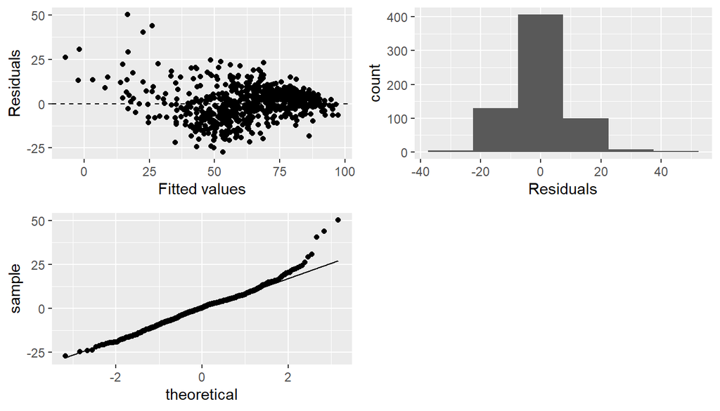

```r
# linearity
p1 <- ggplot(data = final_model , aes(x = .fitted , y = .resid)) + geom_point() + geom_hline(yintercept = 0, linetype = "dashed") +
  xlab("Fitted values") + ylab("Residuals")

# normal
p2 <- ggplot(data = final_model, aes(x = .resid)) + geom_histogram(binwidth = 15) + xlab("Residuals")

p3 <- ggplot(data = final_model , aes(sample = .resid)) + stat_qq() + stat_qq_line() +
  xlab("theoretical") + ylab("sample")

plot_grid(p1, p2, p3)
```

## Part 5: Prediction

We choose Zootopia in 2016. The true audience score for Zootopia in Rotten Tomatoes was 98 and our prediction value is 95.3, which is quite close to the real value.

```r
predicted_movie <- data.frame(genre = "Comedy" ,
                              runtime = 108,
                              best_pic_nom = "yes" ,
                              thtr_rel_month = 2,
                              imdb_rating = 8.0,
                              critics_score = 98,
                              best_actress_win = "no")
predict(final_model , predicted_movie , interval = "prediction" , level = 0.95 )
```

```
##        fit     lwr      upr
## 1 95.34788 75.4991 115.1967
```

## Part 6: Conclusion

The research objetvice was to investigate what parameters have the major influences on the audience score of a movie. Using the model we build with 7 features, we could closely predict the audience score of a movie (Zootopia) which released in 2016. Including more numerical variables such as ticket selling amount might improve the accuracy of our model.